# Nigeria Agric Export Analysis

Lukman

2024-07-08

## Introduction

This analysis is about the export of agricultural products in Nigeria. The aim includes:

- Knowing the agricultural products being exported and also their respective performance in terms of sales and profit.
- Know the countries the products are being exported to and their quantities.
- Gain insight about the companies exporting the products in terms of the quantities exported and income realised.
- Ascertaining the income made from exports and their quantities on a yearly basis from 2020 to 2023.

## Resources Set-Up

Let’s install and load the required package for this analysis which is the tidyverse.

```r
#install.packages(tidyverse) #tidyverse is installed in current environment that's why it's commented out
library(tidyverse)
```

## Dataset For Analysis

### About The Dataset

The dataset to be used is gotten from data.world website. It contains the following columns:

- Product Name - The name of the product.
- Company - The company exporting the product.
- Export Country - The country the product is being exported to.
- Date - The date the product is being exported.
- Units Sold - The number of units of the product exported.
- Unit price - The price of each unit of product exported.
- Profit per Unit - The profit made from each unit exported.
- Export Value - The total sales value from the product exported which is the units sold multiplied by the unit price.
- Destination Port - The port the product is being exported from.
- Transportation Mode - The mode of transportation used to export the product.

### Loading Dataset

Let’s load the dataset using the read.csv function.

```r
nig_agric_exports <- read.csv("C:/Users/U/Desktop/DDP/nigeria_agricultural_exports.csv")
```

Let’s get some information about the data. The head function will be used to give us a brief view of the dataset. The summary function gives us a brief summary of our data. The colnames function helps us know the names of each column. The str function helps us know the structure of the dataset. The class function lets us know we are working with a dataframe.

```r
head(nig_agric_exports)
```

```
##   Product.Name                                   Company Export.Country       Date
## 1       Rubber                  Farmgate Nigeria Limited        Austria 11/16/2023
## 2     Palm Oil        Prime Agro Exports Nigeria Limited        Germany   1/8/2021
## 3      Cassava                  Farmgate Nigeria Limited        Germany 10/14/2020
## 4       Rubber  Nigerian Export Promotion Council (NEPC)        Belgium 12/31/2022
## 5       Sesame               Nigeria Agro Export Company         France 12/19/2022
## 6     Palm Oil Greenfield Agro Exporters Nigeria Limited    Netherlands  7/13/2021
##   Units.Sold unit_price Profit.per.unit Export.Value Destination.Port
## 1        721   31443.05         5863.92     22670439            Lagos
## 2        881   23151.97         5868.73     20396886            Lagos
## 3        702   18536.45         5105.01     13012588          Calabar
## 4        191   21981.31         7781.54      4198430            Warri
## 5        373   13415.94         9590.95      5004146            Lagos
## 6        593   44749.95         4498.48     26536720            Lagos
##   Transportation.Mode
## 1                 Sea
## 2                 Sea
## 3                 Sea
## 4                 Sea
## 5                 Sea
## 6                 Sea
```

```r
summary(nig_agric_exports)
```

```
##  Product.Name         Company          Export.Country         Date
##  Length:1000        Length:1000        Length:1000        Length:1000
##  Class :character   Class :character   Class :character   Class :character
##  Mode  :character   Mode  :character   Mode  :character   Mode  :character
##
##
##
##    Units.Sold      unit_price    Profit.per.unit  Export.Value
##  Min.   :103.0   Min.   :10007   Min.   :2000    Min.   : 1323777
##  1st Qu.:322.8   1st Qu.:20014   1st Qu.:4261    1st Qu.: 7669552
##  Median :519.0   Median :30083   Median :6132    Median :14414511
##  Mean   :536.8   Mean   :30010   Mean   :6125    Mean   :16317664
##  3rd Qu.:743.2   3rd Qu.:39955   3rd Qu.:8038    3rd Qu.:22629691
##  Max.   :999.0   Max.   :49986   Max.   :9991    Max.   :47120823
##  Destination.Port   Transportation.Mode
##  Length:1000        Length:1000
##  Class :character   Class :character
##  Mode  :character   Mode  :character
##
##
##
```

```r
colnames(nig_agric_exports)
```

```
##  [1] "Product.Name"        "Company"             "Export.Country"
##  [4] "Date"                "Units.Sold"          "unit_price"
##  [7] "Profit.per.unit"     "Export.Value"        "Destination.Port"
## [10] "Transportation.Mode"
```

```r
str(nig_agric_exports)
```

```
## 'data.frame':    1000 obs. of  10 variables:
##  $ Product.Name       : chr  "Rubber" "Palm Oil" "Cassava" "Rubber" ...
##  $ Company            : chr  "Farmgate Nigeria Limited" "Prime Agro Exports Nigeria Limited" "Farmgate Nigeria Limited" "Nigerian Export Promotion Council (NEPC)" ...
##  $ Export.Country     : chr  "Austria" "Germany" "Germany" "Belgium" ...
##  $ Date               : chr  "11/16/2023" "1/8/2021" "10/14/2020" "12/31/2022" ...
##  $ Units.Sold         : int  721 881 702 191 373 593 142 990 606 900 ...
##  $ unit_price         : num  31443 23152 18536 21981 13416 ...
##  $ Profit.per.unit    : num  5864 5869 5105 7782 9591 ...
##  $ Export.Value       : num  22670439 20396886 13012588 4198430 5004146 ...
##  $ Destination.Port   : chr  "Lagos" "Lagos" "Calabar" "Warri" ...
##  $ Transportation.Mode: chr  "Sea" "Sea" "Sea" "Sea" ...
```

```r
class(nig_agric_exports)
```

```
## [1] "data.frame"
```

## Data Processing

From the information we got about our data, we can see that the date column is of character type which should not be. We can change the date column to a date type using the as.Date and use the str function to confirm the change we made.

```r
nig_agric_exports$Date <- as.Date(nig_agric_exports$Date, format = "%m/%d/%Y")
str(nig_agric_exports)
```

```
## 'data.frame':    1000 obs. of  10 variables:
##  $ Product.Name       : chr  "Rubber" "Palm Oil" "Cassava" "Rubber" ...
##  $ Company            : chr  "Farmgate Nigeria Limited" "Prime Agro Exports Nigeria Limited" "Farmgate Nigeria Limited" "Nigerian Export Promotion Council (NEPC)" ...
##  $ Export.Country     : chr  "Austria" "Germany" "Germany" "Belgium" ...
##  $ Date               : Date, format: "2023-11-16" "2021-01-08" ...
##  $ Units.Sold         : int  721 881 702 191 373 593 142 990 606 900 ...
##  $ unit_price         : num  31443 23152 18536 21981 13416 ...
##  $ Profit.per.unit    : num  5864 5869 5105 7782 9591 ...
##  $ Export.Value       : num  22670439 20396886 13012588 4198430 5004146 ...
##  $ Destination.Port   : chr  "Lagos" "Lagos" "Calabar" "Warri" ...
##  $ Transportation.Mode: chr  "Sea" "Sea" "Sea" "Sea" ...
```

## Data Manipulation

We will be needing to add some columns to our dataset to help us in our analysis. The dataset includes the profit per unit but we were not given the total profit made so we will have to add to total profit column which is the multiplication of the units sold and the profit per unit. We will also be needing to extract the year from the date column and add it as a new column so we get to know the year each product were exported.

```r
nig_agric_exports <- mutate(nig_agric_exports, Total_profit = Units.Sold * Profit.per.unit, Year = year(Date))
head(nig_agric_exports)
```

```
##   Product.Name                                   Company Export.Country       Date
## 1       Rubber                  Farmgate Nigeria Limited        Austria 2023-11-16
## 2     Palm Oil        Prime Agro Exports Nigeria Limited        Germany 2021-01-08
## 3      Cassava                  Farmgate Nigeria Limited        Germany 2020-10-14
## 4       Rubber  Nigerian Export Promotion Council (NEPC)        Belgium 2022-12-31
## 5       Sesame               Nigeria Agro Export Company         France 2022-12-19
## 6     Palm Oil Greenfield Agro Exporters Nigeria Limited    Netherlands 2021-07-13
##   Units.Sold unit_price Profit.per.unit Export.Value Destination.Port
## 1        721   31443.05         5863.92     22670439            Lagos
## 2        881   23151.97         5868.73     20396886            Lagos
## 3        702   18536.45         5105.01     13012588          Calabar
## 4        191   21981.31         7781.54      4198430            Warri
## 5        373   13415.94         9590.95      5004146            Lagos
## 6        593   44749.95         4498.48     26536720            Lagos
##   Transportation.Mode Total_profit Year
## 1                 Sea      4227886 2023
## 2                 Sea      5170351 2021
## 3                 Sea      3583717 2020
## 4                 Sea      1486274 2022
## 5                 Sea      3577424 2022
## 6                 Sea      2667599 2021
```

Our dataset looks good, lets do some analysis.

## Data Analysis

### Total Profit and Export Value Made From 2020 to 2023

Firstly, lets know the total profit and export value made on a yearly basis on agricultural products from 2020 to 2023.

```r
yearly_returns <- nig_agric_exports %>% drop_na() %>% group_by(Year) %>% summarize(Export_Value = sum(Export.Value, na.rm = TRUE), Total_profit = sum(Total_profit, na.rm = TRUE)) %>% arrange(-Export_Value)
yearly_returns
```

```
## # A tibble: 4 × 3
##    Year Export_Value Total_profit
##   <dbl>        <dbl>        <dbl>
## 1  2021  4461997758.   878046721.
## 2  2023  4187770808.   806495021.
## 3  2020  3891727250.   837690929.
## 4  2022  3776168663.   766216485.
```

### Total Units, Profits and Export value Made On Each Products

```r
Product_returns <- nig_agric_exports %>% drop_na() %>% group_by(Product.Name) %>% summarize(Export_value = sum(Export.Value, na.rm = TRUE), Total_Units = sum(Units.Sold, na.rm = TRUE), Total_profit = sum(Total_profit, na.rm = TRUE)) %>% arrange(-Export_value)
Product_returns
```

```
## # A tibble: 8 × 4
##   Product.Name Export_value Total_Units Total_profit
##   <chr>               <dbl>       <int>        <dbl>
## 1 Cocoa         2384888721.       76129   450351412.
## 2 Sesame        2268607547.       76132   477487003.
## 3 Rubber        2118009971.       66641   395731339.
## 4 Cashew        2110678804.       70833   438624304.
## 5 Palm Oil      1974585532.       63879   385392111.
## 6 Plantain      1947169761.       64863   387736296.
## 7 Cassava       1913308279.       64234   416503461.
## 8 Ginger        1600415864.       54093   336623229.
```

### Income Realised From Agricultural Product Export By Each Company

```r
Company_returns <- nig_agric_exports %>% drop_na() %>% group_by(Company) %>% summarize(Export_value = sum(Export.Value, na.rm = TRUE), Total_profit = sum(Total_profit, na.rm = TRUE)) %>% arrange(-Export_value)
Company_returns
```

```
## # A tibble: 10 × 3
##    Company                                   Export_value Total_profit
##    <chr>                                            <dbl>        <dbl>
##  1 Agro Export Nigeria Ltd                    1867914625.   383051968.
##  2 Golden Farms Nigeria Limited               1732721290.   371301965.
##  3 Prime Agro Exports Nigeria Limited         1706071644.   315610855.
##  4 Nigeria Agro Export Company                1704147641.   325659628.
##  5 Nigerian Export Promotion Council (NEPC)   1647087955.   345639630.
##  6 Farmgate Nigeria Limited                   1615237652.   336966269.
##  7 Solid Agro Nigeria Limited                 1541529741.   311948627.
##  8 Greenfield Agro Exporters Nigeria Limited  1506892571.   309214754.
##  9 Agriplus Nigeria Limited                   1503023344.   306226282.
## 10 Agro Allied Exporters Nigeria Limited      1493038016.   282829178.
```

### Total Export Value Made From Each Export Country

```r
export_country_info <- nig_agric_exports %>% drop_na() %>% group_by(Export.Country) %>% summarize(Export_value = sum(Export.Value, na.rm = TRUE)) %>% arrange(-Export_value)
export_country_info
```

```
## # A tibble: 10 × 2
##    Export.Country Export_value
##    <chr>                 <dbl>
##  1 Italy           1962586623.
##  2 Denmark         1831246093.
##  3 France          1805863663.
##  4 Switzerland     1663789720.
##  5 Belgium         1605706575.
##  6 Netherlands     1534358435.
##  7 Austria         1530520957.
##  8 Sweden          1497262526.
##  9 Spain           1489988920.
## 10 Germany         1396340968.
```

### Agricultural Products Exported to Italy Between 2020 to 2023

```r
Italy_info <- nig_agric_exports %>% drop_na() %>% filter(Export.Country == "Italy") %>% group_by(Product.Name) %>% summarize(Export_value = sum(Export.Value, na.rm = TRUE)) %>% arrange(-Export_value)
Italy_info
```

```
## # A tibble: 8 × 2
##   Product.Name Export_value
##   <chr>               <dbl>
## 1 Sesame         394283944.
## 2 Palm Oil       329902312.
## 3 Rubber         313521760.
## 4 Plantain       284615838.
## 5 Cassava        200574735.
## 6 Cocoa          192738381.
## 7 Cashew         140735705.
## 8 Ginger         106213948.
```

### Total Units and Export Value Of Cocoa Exported to Each Country

```r
cocoa_buyers <- nig_agric_exports %>% drop_na() %>% filter(Product.Name == "Cocoa") %>% group_by(Export.Country) %>% summarize(Export_value = sum(Export.Value, na.rm = TRUE), Total_Units = sum(Units.Sold, na.rm = TRUE)) %>% arrange(-Export_value)
cocoa_buyers
```

```
## # A tibble: 10 × 3
##    Export.Country Export_value Total_Units
##    <chr>                 <dbl>       <int>
##  1 France           397164699.       11220
##  2 Sweden           363773707.       11514
##  3 Spain            304863274.        9113
##  4 Denmark          268289709.        8618
##  5 Austria          266200623.        8358
##  6 Italy            192738381.        5465
##  7 Belgium          188191080.        5749
##  8 Netherlands      171336562.        5810
##  9 Germany          158898529.        7423
## 10 Switzerland       73432157.        2859
```

### Income From Cocoa Exported By Different Companies

```r
cocoa_exporters <- nig_agric_exports %>% drop_na() %>% filter(Product.Name == "Cocoa") %>% group_by(Company) %>% summarize(Export_value = sum(Export.Value, na.rm = TRUE), Total_Units = sum(Units.Sold, na.rm = TRUE), Total_profit = sum(Total_profit, na.rm = TRUE)) %>% arrange(-Export_value)
cocoa_exporters
```

```
## # A tibble: 10 × 4
##    Company                                   Export_value Total_Units Total_profit
##    <chr>                                            <dbl>       <int>        <dbl>
##  1 Nigerian Export Promotion Council (NEPC)    314084178.        9612    49765715.
##  2 Greenfield Agro Exporters Nigeria Limited   306612067.        8204    51142746.
##  3 Golden Farms Nigeria Limited                298758402.       11234    76992878.
##  4 Prime Agro Exports Nigeria Limited          258859484.        7490    45573578.
##  5 Agro Allied Exporters Nigeria Limited       240269590.        8342    49615832.
##  6 Solid Agro Nigeria Limited                  217069247.        6730    39144019.
##  7 Farmgate Nigeria Limited                    208316490.        7293    38766573.
##  8 Agriplus Nigeria Limited                    201351458.        6324    37866536.
##  9 Agro Export Nigeria Ltd                     191960361.        5560    36792409.
## 10 Nigeria Agro Export Company                 147607444.        5340    24691124.
```

### Total Units and Value Of Cocoa Exported From 2020 to 2023

```r
yearly_cocoa_export <- nig_agric_exports %>% drop_na() %>% filter(Product.Name == "Cocoa") %>% group_by(Year) %>% summarize(Export_value = sum(Export.Value, na.rm = TRUE), Total_Units = sum(Units.Sold, na.rm = TRUE), Total_profit = sum(Total_profit, na.rm = TRUE)) %>% arrange(-Export_value)
yearly_cocoa_export
```

```
## # A tibble: 4 × 4
##    Year Export_value Total_Units Total_profit
##   <dbl>        <dbl>       <int>        <dbl>
## 1  2023   754365695.       22787   140694752.
## 2  2022   623771078        20283   122300820.
## 3  2021   517359544.       16398    94824439.
## 4  2020   489392404.       16661    92531401.
```

## Data Visualization

Let’s use some visuals to help communicate our data better.

### Export Value From 2020 to 2023

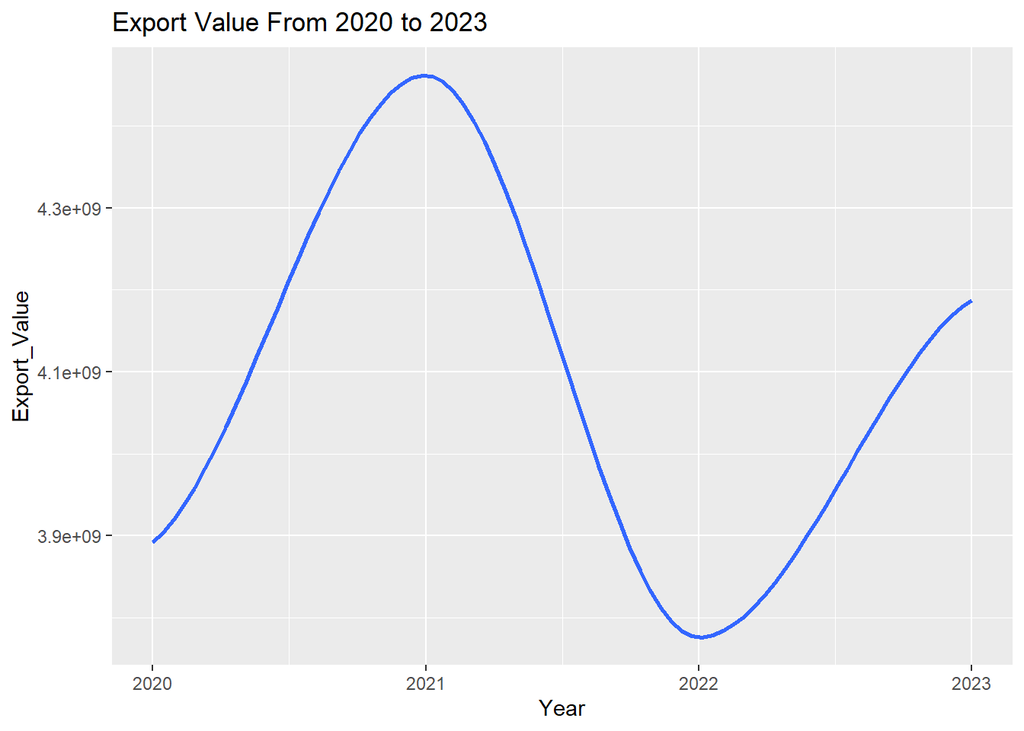

```r
ggplot(data = yearly_returns) +
  geom_smooth(mapping = aes(x = Year, y = Export_Value))+
  labs(title = "Export Value From 2020 to 2023")
```

### Export Profit From 2020 to 2023

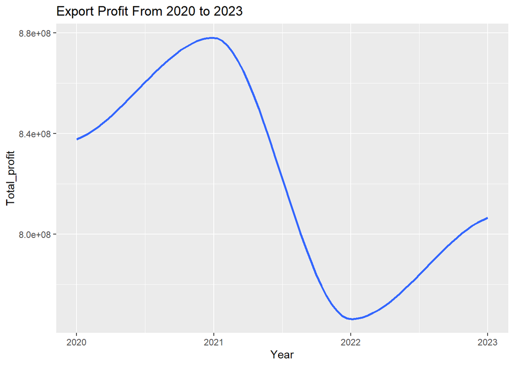

```r
ggplot(data = yearly_returns) +
  geom_smooth(mapping = aes(x = Year, y = Total_profit))+
  labs(title = "Export Profit From 2020 to 2023")
```

### Total Export Value By Product Between 2020 to 2023

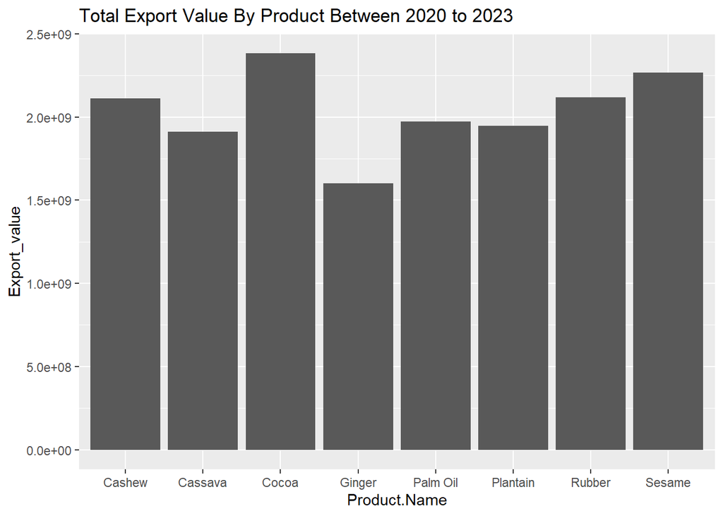

```r
ggplot(data = Product_returns) +
  geom_col(mapping = aes(x = Product.Name, y = Export_value))+
  labs(title = "Total Export Value By Product Between 2020 to 2023")
```

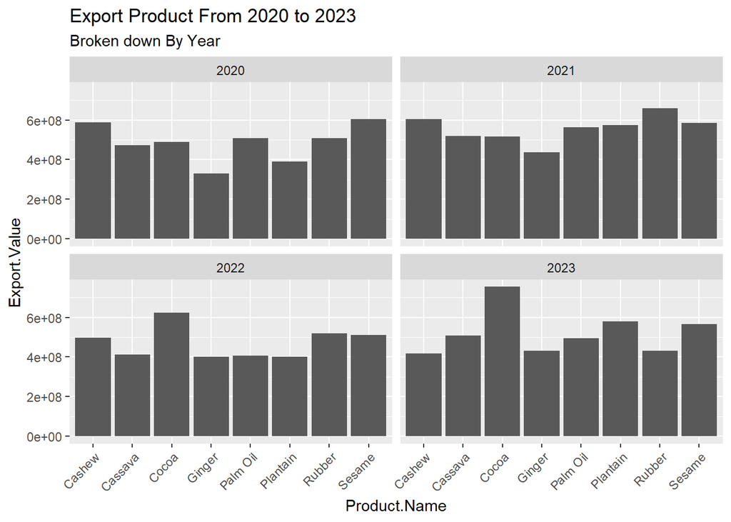

```r
ggplot(data = nig_agric_exports)+
  geom_col(mapping = aes(x = Product.Name, y = Export.Value))+
  facet_wrap(~Year)+
  theme(axis.text.x = element_text(angle = 45, hjust = 1))+
  labs(title = "Export Product From 2020 to 2023", subtitle = "Broken down By Year")
```

### Total Export Value Between 2020 to 2023 Broken Down By Product

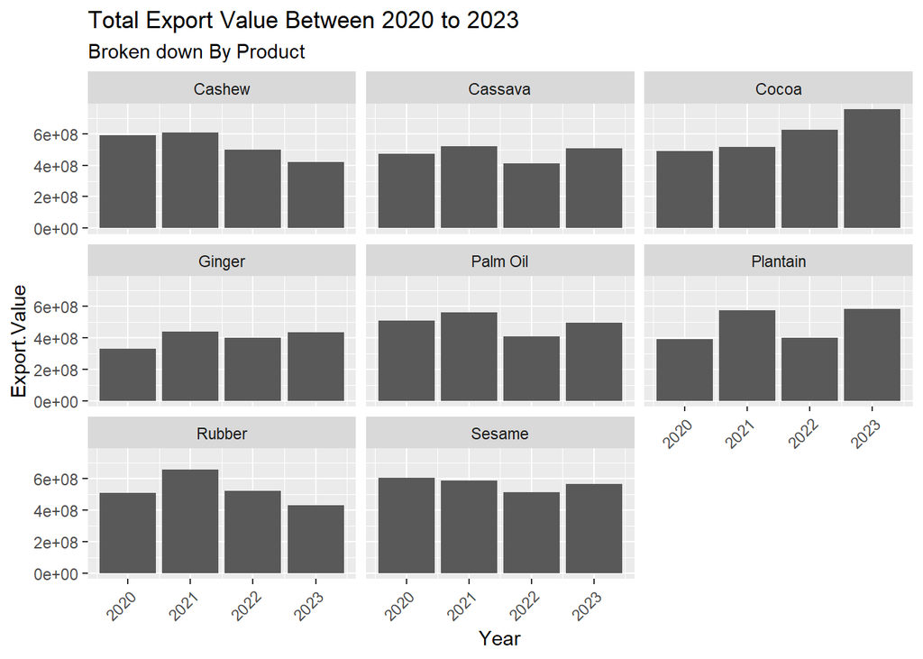

```r
ggplot(data = nig_agric_exports)+
  geom_col(mapping = aes(x = Year, y = Export.Value))+
  facet_wrap(~Product.Name)+
  theme(axis.text.x = element_text(angle = 45, hjust = 1))+
  labs(title = "Total Export Value Between 2020 to 2023", subtitle = "Broken down By Product")
```

### Total Profit Made By Companies

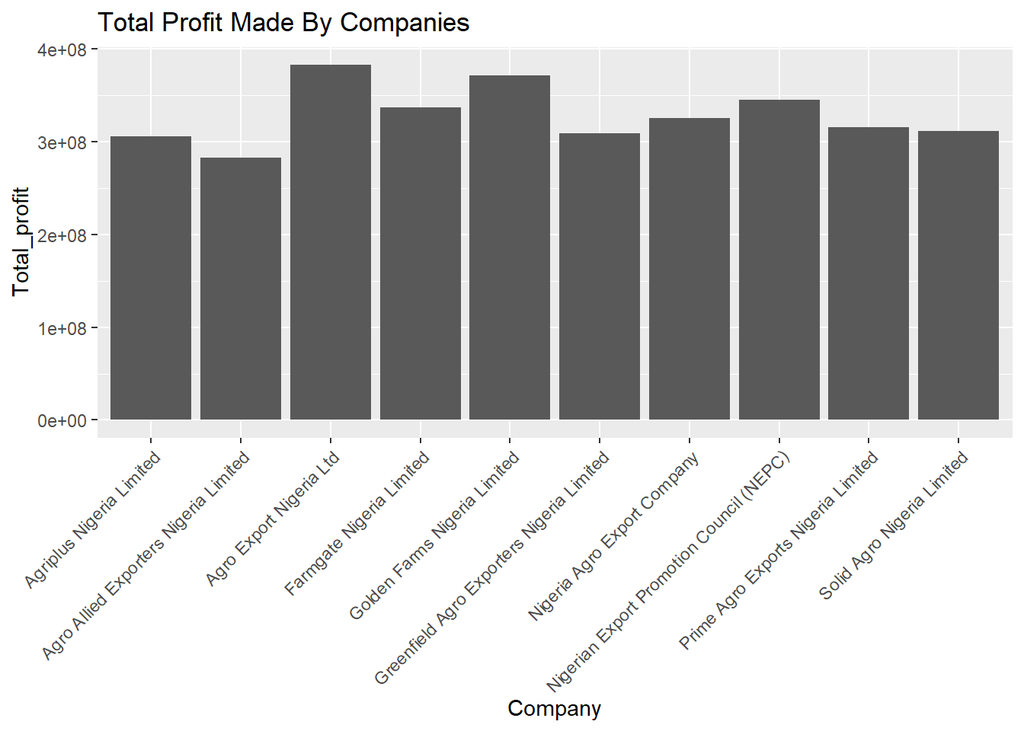

```r
ggplot(data = Company_returns)+
  geom_col(mapping = aes(x = Company, y = Total_profit))+
  theme(axis.text.x = element_text(angle = 45, hjust = 1))+
  labs(title = "Total Profit Made By Companies")
```

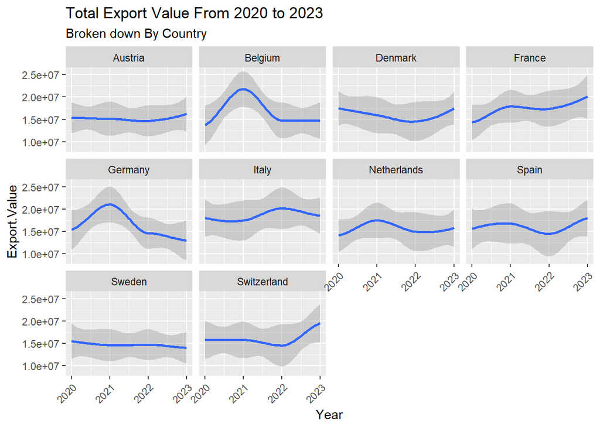

```r
ggplot(data = nig_agric_exports)+
  geom_smooth(mapping = aes(x = Year, y = Export.Value))+
  facet_wrap(~Export.Country)+
  theme(axis.text.x = element_text(angle = 45, hjust = 1))+
  labs(title = "Total Export Value From 2020 to 2023", subtitle = "Broken down By Country")
```

### Export Value By Country From 2020 to 2023

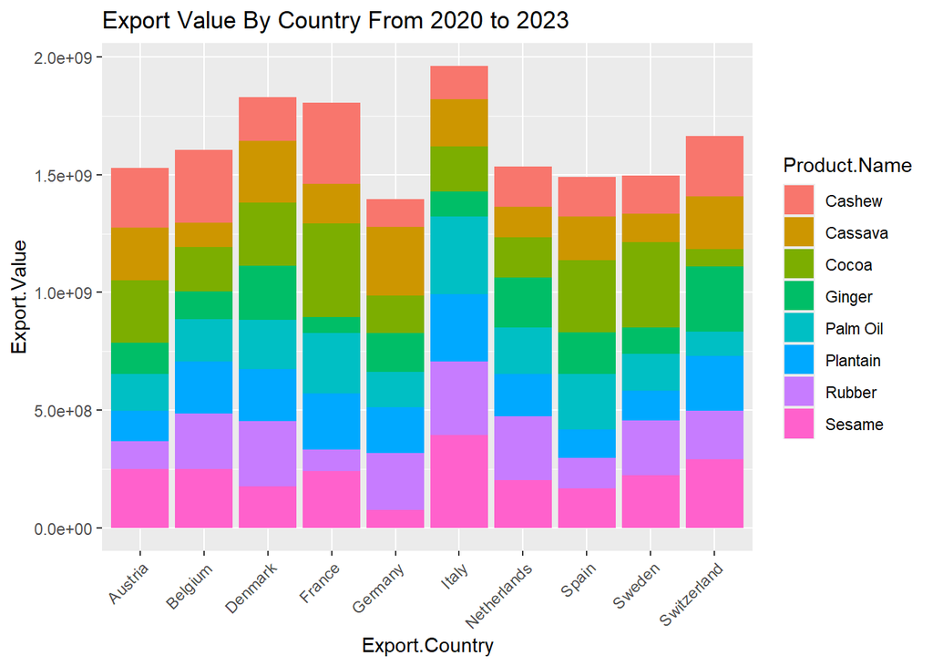

```r
ggplot(data = nig_agric_exports)+
  geom_col(mapping = aes(x = Export.Country, y = Export.Value, fill = Product.Name))+
  theme(axis.text.x = element_text(angle = 45, hjust = 1))+
  labs(title = ("Export Value By Country From 2020 to 2023"))
```

### Product Units Sold to Countries From 2020 to 2023

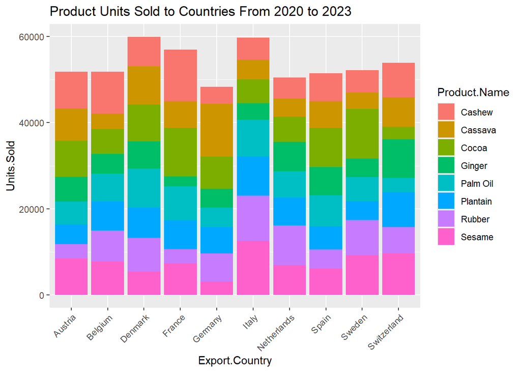

```r
ggplot(data = nig_agric_exports)+
  geom_col(mapping = aes(x = Export.Country, y = Units.Sold, fill = Product.Name))+
  theme(axis.text.x = element_text(angle = 45, hjust = 1))+
  labs(title = ("Product Units Sold to Countries From 2020 to 2023"))
```

### Quantities Of Cocoa Exported From 2020 to 2023

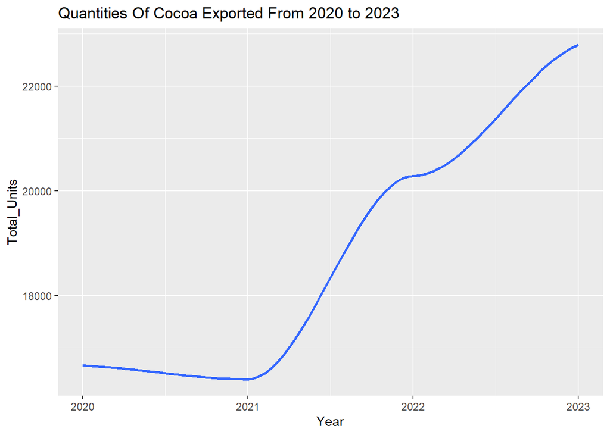

```r
ggplot(data = yearly_cocoa_export)+
  geom_smooth(mapping = aes(x = Year, y = Total_Units))+
  labs(title = "Quantities Of Cocoa Exported From 2020 to 2023")
```

### Quantities Of Cocoa Purchased By Different Countries

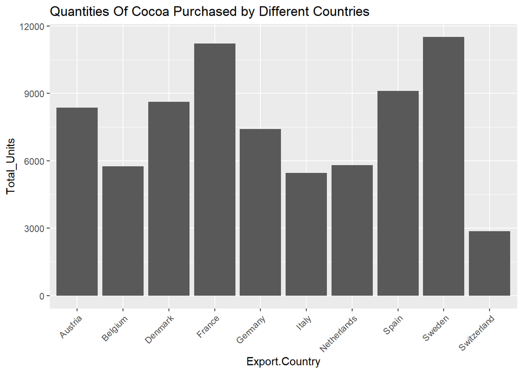

```r
ggplot(data = cocoa_buyers)+
  geom_col(mapping = aes(x = Export.Country, y = Total_Units))+
  theme(axis.text.x = element_text(angle = 45, hjust = 1))+
  labs(title = "Quantities Of Cocoa Purchased by Different Countries")
```

### Proportion Of Cocoa Units Exported By Companies

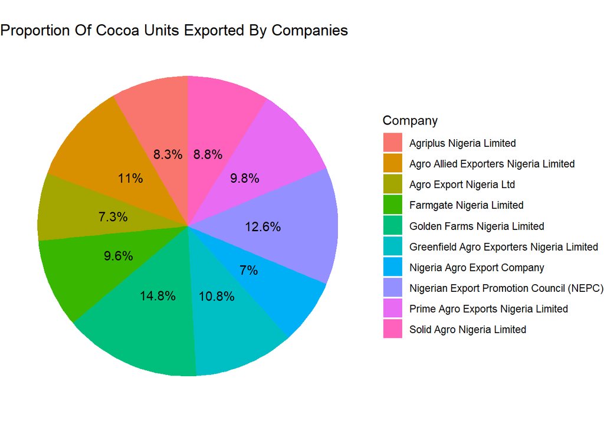

```r
cocoa_exporters$percentage <- round(cocoa_exporters$Total_Units /sum(cocoa_exporters$Total_Units) * 100, 1)
ggplot(cocoa_exporters, aes(x="", y = Total_Units, fill = Company)) +
  geom_bar(width = 1, stat = "identity") +
  coord_polar(theta = "y") +
  labs(title = "Proportion Of Cocoa Units Exported By Companies") +
  theme_void() +
  geom_text(aes(label = paste0(percentage, "%")),position = position_stack(vjust = 0.5))
```

### Quantities Of Cocoa Exported By Companies

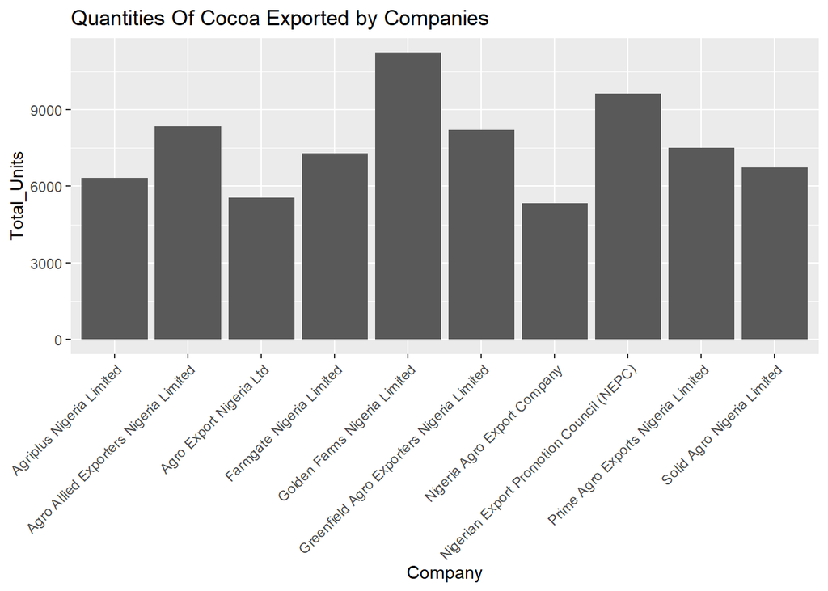

```r
ggplot(data = cocoa_exporters)+
  geom_col(mapping = aes(x = Company, y = Total_Units))+
  theme(axis.text.x = element_text(angle = 45, hjust = 1))+
  labs(title = "Quantities Of Cocoa Exported by Companies")
```

### Profit Made By Companies From Cocoa Exported

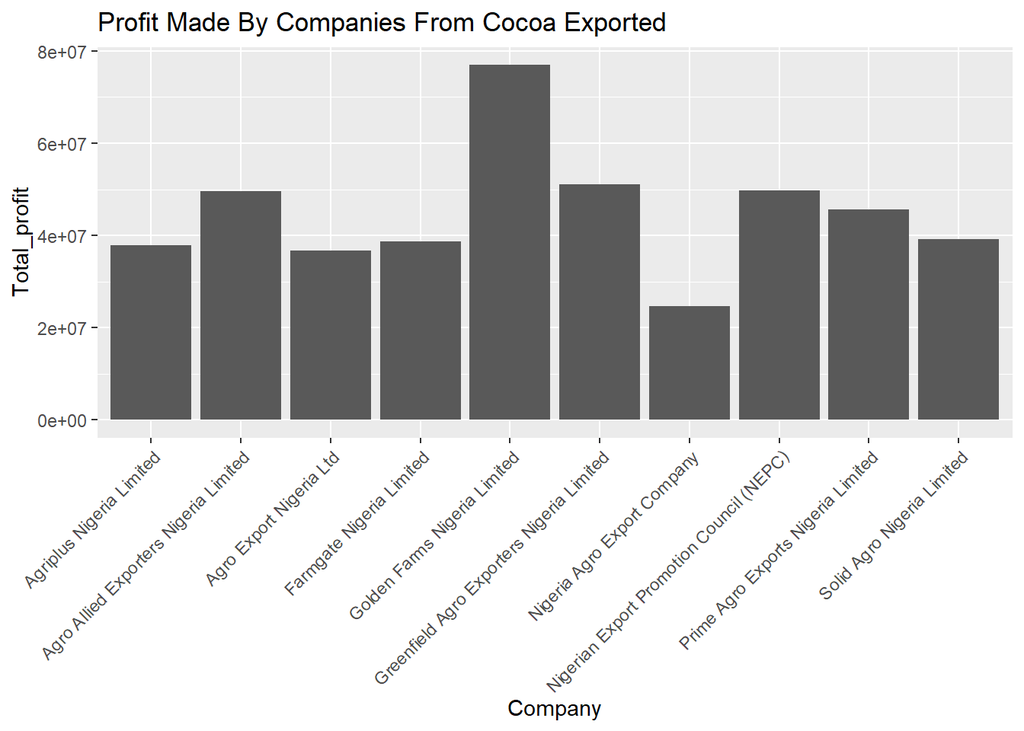

```r
ggplot(data = cocoa_exporters)+
  geom_col(mapping = aes(x = Company, y = Total_profit))+
  theme(axis.text.x = element_text(angle = 45, hjust = 1))+
  labs(title = "Profit Made By Companies From Cocoa Exported")
```